# Homework 2

## Chapter 4: Questions 14

In this problem, you will develop a model to predict whether a given car gets high or low gas mileage based on the Auto data set.

```python
import numpy as np
import pandas as pd
import statsmodels.api as sm
from ISLP import load_data
from ISLP.models import (ModelSpec as MS,
                         summarize,
                         poly)
from sklearn.model_selection import train_test_split
from functools import partial
from sklearn.model_selection import \
     (cross_validate,
      KFold,
      ShuffleSplit)
from sklearn.base import clone
from ISLP.models import sklearn_sm
import matplotlib.pyplot as plt
import seaborn as sns
from sklearn.discriminant_analysis import \
     (LinearDiscriminantAnalysis as LDA,
      QuadraticDiscriminantAnalysis as QDA)
from sklearn.metrics import accuracy_score
from sklearn.linear_model import LogisticRegression
from sklearn.naive_bayes import GaussianNB
from sklearn.linear_model import LinearRegression
from sklearn.model_selection import LeaveOneOut
from sklearn.preprocessing import PolynomialFeatures
from sklearn.metrics import mean_squared_error
```

```python
Auto = load_data("Auto")
Auto.head(5)
```

| name | mpg | cylinders | displacement | horsepower | weight | acceleration | year | origin |
| --- | --- | --- | --- | --- | --- | --- | --- | --- |
| chevrolet chevelle malibu | 18.0 | 8 | 307.0 | 130 | 3504 | 12.0 | 70 | 1 |
| buick skylark 320 | 15.0 | 8 | 350.0 | 165 | 3693 | 11.5 | 70 | 1 |
| plymouth satellite | 18.0 | 8 | 318.0 | 150 | 3436 | 11.0 | 70 | 1 |
| amc rebel sst | 16.0 | 8 | 304.0 | 150 | 3433 | 12.0 | 70 | 1 |
| ford torino | 17.0 | 8 | 302.0 | 140 | 3449 | 10.5 | 70 | 1 |

(a) Create a binary variable, mpg01, that contains a 1 if mpg contains a value above its median, and a 0 if mpg contains a value below its median. You can compute the median using the median() method of the data frame. Note you may fnd it helpful to add a column mpg01 to the data frame by assignment. Assuming you have stored the data frame as Auto, this can be done as follows:

```python
mpg01 = []
for i in Auto["mpg"]:
    if i > np.median(Auto["mpg"]):
        mpg01.append(1)
    if i < np.median(Auto["mpg"]):
        mpg01.append(0)

Auto["mpg01"]=mpg01
print(Auto.head(5))
```

```
                            mpg  cylinders  displacement  horsepower  weight  \
name
chevrolet chevelle malibu  18.0          8         307.0         130    3504
buick skylark 320          15.0          8         350.0         165    3693
plymouth satellite         18.0          8         318.0         150    3436
amc rebel sst              16.0          8         304.0         150    3433
ford torino                17.0          8         302.0         140    3449

                           acceleration  year  origin  mpg01
name
chevrolet chevelle malibu          12.0    70       1      0
buick skylark 320                  11.5    70       1      0
plymouth satellite                 11.0    70       1      0
amc rebel sst                      12.0    70       1      0
ford torino                        10.5    70       1      0
```

(b) Explore the data graphically in order to investigate the association between mpg01 and the other features. Which of the other features seem most likely to be useful in predicting mpg01? Scatterplots and boxplots may be useful tools to answer this question. Describe your fndings.

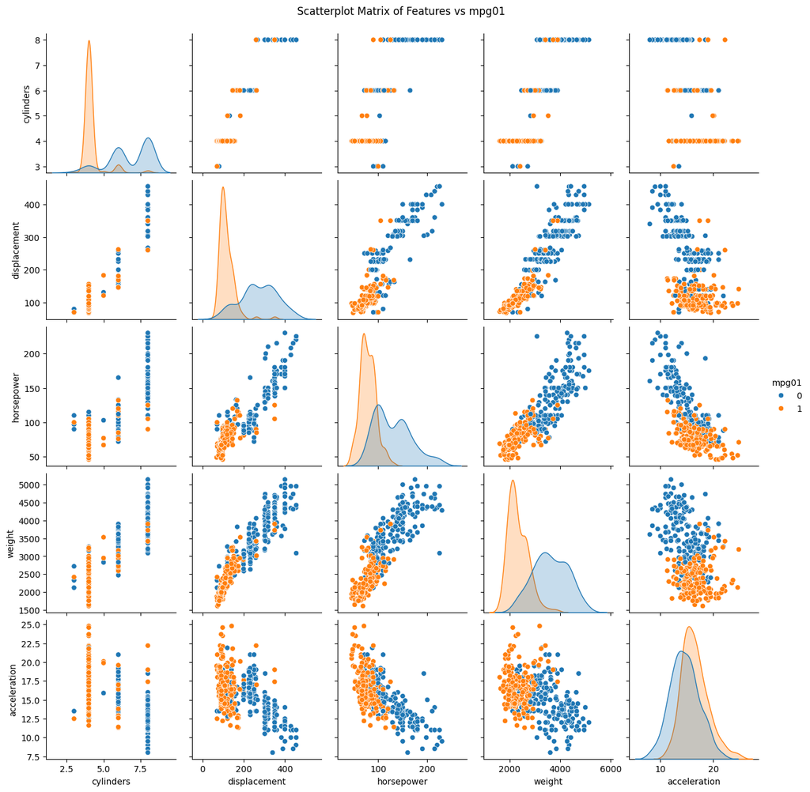

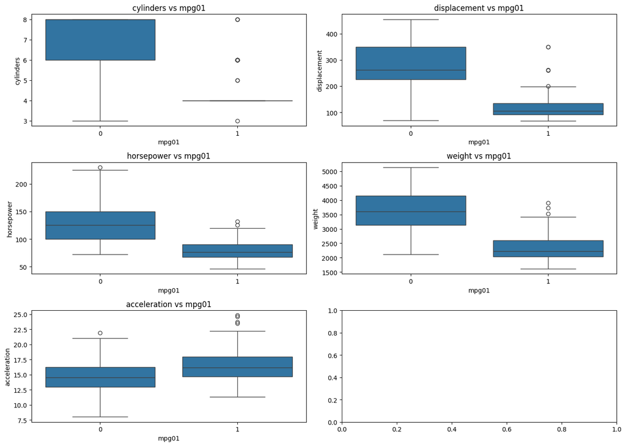

```python
sns.pairplot(Auto, hue='mpg01', vars=['cylinders', 'displacement', 'horsepower', 'weight', 'acceleration'])
plt.suptitle('Scatterplot Matrix of Features vs mpg01', y=1.02)
plt.show()


features = ['cylinders', 'displacement', 'horsepower', 'weight', 'acceleration']
fig, axes = plt.subplots(nrows=3, ncols=2, figsize=(14, 10))

for i, feature in enumerate(features):
    row, col = divmod(i, 2)
    sns.boxplot(x='mpg01', y=feature, data=Auto, ax=axes[row, col])
    axes[row, col].set_title(f'{feature} vs mpg01')

plt.tight_layout()
plt.show()
```

(c) Split the data into a training set and a test set.

```python
X = Auto[features]
y = Auto["mpg01"]
X_train, X_test, y_train, y_test = train_test_split(X, y, test_size=0.3, random_state=42)
```

(d) Perform LDA on the training data in order to predict mpg01 using the variables that seemed most associated with mpg01 in (b). What is the test error of the model obtained?

```python
lda = LDA()
lda.fit(X_train[["displacement","cylinders"]], y_train) # I choose displacement and cylinders as the most associated predictors

y_lda_pred = lda.predict(X_test[["displacement","cylinders"]])
test_accuracy_lda = accuracy_score(y_test, y_lda_pred)
print("LDA test error is: ",1-test_accuracy_lda)
```

```
LDA test error is:  0.15254237288135597
```

(e) Perform QDA on the training data in order to predict mpg01 using the variables that seemed most associated with mpg01 in (b). What is the test error of the model obtained?

```python
qda = QDA()
qda.fit(X_train[["displacement","cylinders"]], y_train) # I choose displacement and cylinders as the most associated predictor

y_qda_pred = qda.predict(X_test[["displacement","cylinders"]])
test_accuracy_qda = accuracy_score(y_test, y_qda_pred)
print("QDA test error is: ",1-test_accuracy_qda)
```

```
QDA test error is:  0.13559322033898302
```

(f) Perform logistic regression on the training data in order to predict mpg01 using the variables that seemed most associated with mpg01 in (b). What is the test error of the model obtained?

```python
log_reg = LogisticRegression()
log_reg.fit(X_train[["displacement","cylinders"]], y_train)

y_log_pred = log_reg.predict(X_test[["displacement","cylinders"]])
test_accuracy_log = accuracy_score(y_test, y_log_pred)

print("LogisticRegression test error is: ",1-test_accuracy_log)
```

```
LogisticRegression test error is:  0.1610169491525424
```

(g) Perform naive Bayes on the training data in order to predict mpg01 using the variables that seemed most associated with mpg01 in (b). What is the test error of the model obtained?

```python
nb_model = GaussianNB()
nb_model.fit(X_train[["displacement","cylinders"]], y_train)

y_nb_pred = nb_model.predict(X_test[["displacement","cylinders"]])

test_accuracy_nb = accuracy_score(y_test, y_nb_pred)
print("naive Bayes test error is: ",1-test_accuracy_nb)
```

```
naive Bayes test error is:  0.13559322033898302
```

(h) Perform KNN on the training data, with several values of K, in order to predict mpg01. Use only the variables that seemed most associated with mpg01 in (b). What test errors do you obtain? Which value of K seems to perform the best on this data set?

```python
from sklearn.neighbors import KNeighborsClassifier

k_values = [1, 3, 5, 7, 9]
test_errors_knn = {}

for k in k_values:
    knn = KNeighborsClassifier(n_neighbors=k)
    knn.fit(X_train[["displacement","cylinders"]], y_train)
    y_knn_pred = knn.predict(X_test[["displacement","cylinders"]])
    test_accuracy_knn = accuracy_score(y_test, y_knn_pred)
    test_errors_knn[k] = 1 - test_accuracy_knn

print(test_errors_knn)
```

```
{1: 0.17796610169491522, 3: 0.13559322033898302, 5: 0.15254237288135597, 7: 0.15254237288135597, 9: 0.15254237288135597}
```

K=3 seems to perform the best on this data set, because when K=3 it has smallest test_errors.

## Chapter 4 Question 15

(a) Write a function, Power(), that prints out the result of raising 2 to the 3rd power. In other words, your function should compute 23 and print out the results. Hint: Recall that x**a raises x to the power a. Use the print() function to display the result

```python
def Power():
    print(2**3)
Power()
```

```
8
```

(b) Create a new function, Power2(), that allows you to pass any two numbers, x and a, and prints out the value of x**a. You can do this by beginning your function with the line def Power2(x, a): You should be able to call your function by entering, for instance, Power2(3, 8) on the command line. This should output the value of 38, namely, 6, 561.

```python
def Power2(x,a):
    print(x**a)
Power2(3,8)
```

```
6561
```

(c) Using the Power2() function that you just wrote, compute 103, 817, and 1313

```python
Power2(10,3)
Power2(8,17)
Power2(131,3)
```

```
1000
2251799813685248
2248091
```

(d) Now create a new function, Power3(), that actually returns the result x**a as a Python object, rather than simply printing it to the screen. That is, if you store the value x**a in an object called result within your function, then you can simply return return this result, using the following line: return result Note that the line above should be the last line in your function, and it should be indented 4 spaces.

```python
def Power3(x,a):
    result = x**a
    return result
```

(e) Now using the Power3() function, create a plot of f(x) = x2. The x-axis should display a range of integers from 1 to 10, and the y-axis should display x2. Label the axes appropriately, and use an appropriate title for the fgure. Consider displaying either the x-axis, the y-axis, or both on the log-scale. You can do this by using the ax.set_xscale() and ax.set_yscale() methods of .set_xscale() .set_yscale() the axes you are plotting to

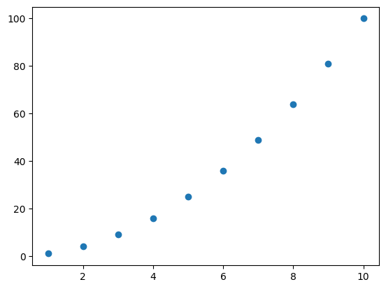

```python
a = 2
x = np.arange(1, 11)
fig, ax = plt.subplots()
ax.scatter(x, Power3(x,a), marker='o')
plt.show()
#ax.set_xscale()
```

(f) Create a function, PlotPower(), that allows you to create a plot of x against x**a for a fxed a and a sequence of values of x. For instance, if you call PlotPower(np.arange(1, 11), 3) then a plot should be created with an x-axis taking on values 1, 2,..., 10, and a y-axis taking on values 13, 23,..., 103.

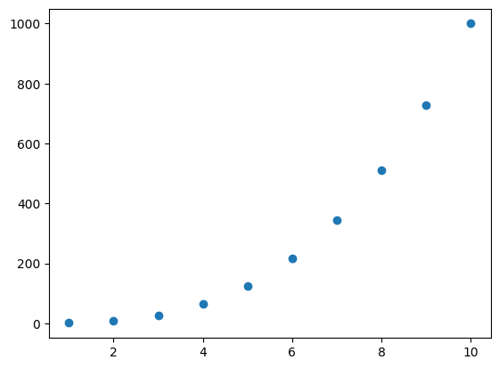

```python
def PlotPower(range_x,a):
    x = range_x
    a = a
    fig, ax = plt.subplots()
    ax.scatter(x, Power3(x,a), marker='o')
    plt.show()
PlotPower(np.arange(1, 11),3)
```

## Chapter 5 Question 8

(a) Generate a simulated data set as follows:

```python
rng = np.random.default_rng(1)
x = rng.normal(size=100)
y = x - 2 * x**2 + rng.normal(size=100)
```

n = 100 and p = 1. $$ y = x - 2x^2 + ϵ $$

(b) Create a scatterplot of X against Y . Comment on what you fnd

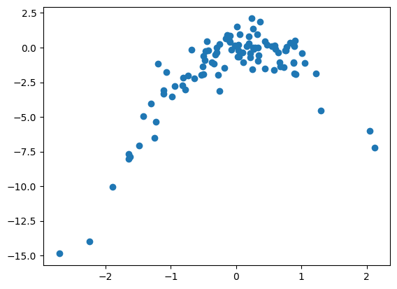

```python
fig, ax = plt.subplots()
ax.scatter(x,y, marker='o')
plt.show()
```

Because x is generated according to normal distribution, there are a large number of sample points in the center, but only a small number of samples on either side. Also we can observe the effect of introducing an error term with some noise.

(c) Set a random seed, and then compute the LOOCV errors that result from ftting the following four models using least squares: i. Y = β0 + β1X + " ii. Y = β0 + β1X + β2X2 + " iii. Y = β0 + β1X + β2X2 + β3X3 + " iv. Y = β0 + β1X + β2X2 + β3X3 + β4X4 + ". Note you may fnd it helpful to use the data.frame() function to create a single data set containing both X and Y .

```python
data = pd.DataFrame({'X': x, 'Y': y})
degrees = [1, 2, 3, 4]
loocv = LeaveOneOut()
loocv_errors = []

for i in degrees:
    poly = PolynomialFeatures(i)
    X_poly = poly.fit_transform(data[['X']])
    model = LinearRegression()

    squared_errors = []

    for train_index, test_index in loocv.split(X_poly):
        X_train, X_test = X_poly[train_index], X_poly[test_index]
        y_train, y_test = y[train_index], y[test_index]
        model.fit(X_train, y_train)
        y_pred = model.predict(X_test)
        squared_errors.append((y_test - y_pred)**2)

    loocv_error = np.mean(squared_errors)
    loocv_errors.append(loocv_error)

loocv_df = pd.DataFrame({'Degree': degrees,'LOOCV Error': loocv_errors})
loocv_df
```

|  | Degree | LOOCV Error |
| --- | --- | --- |
| 0 | 1 | 7.964550 |
| 1 | 2 | 1.312915 |
| 2 | 3 | 1.357203 |
| 3 | 4 | 1.403687 |

(d) Repeat (c) using another random seed, and report your results. Are your results the same as what you got in (c)? Why?

```python
rng = np.random.default_rng(5)
x = rng.normal(size=100)
y = x - 2 * x**2 + rng.normal(size=100)
data = pd.DataFrame({'X': x, 'Y': y})
loocv_errors = []

for i in degrees:
    poly = PolynomialFeatures(i)
    X_poly = poly.fit_transform(data[['X']])
    model = LinearRegression()

    squared_errors = []

    for train_index, test_index in loocv.split(X_poly):
        X_train, X_test = X_poly[train_index], X_poly[test_index]
        y_train, y_test = y[train_index], y[test_index]
        model.fit(X_train, y_train)
        y_pred = model.predict(X_test)
        squared_errors.append((y_test - y_pred)**2)

    loocv_error = np.mean(squared_errors)
    loocv_errors.append(loocv_error)

loocv_df = pd.DataFrame({'Degree': degrees,'LOOCV Error': loocv_errors})
loocv_df
```

|  | Degree | LOOCV Error |
| --- | --- | --- |
| 0 | 1 | 6.089221 |
| 1 | 2 | 1.053718 |
| 2 | 3 | 1.087251 |
| 3 | 4 | 1.265553 |

The result is different from (c), because when we set a different seed our dataset also changes.

(e) Which of the models in (c) had the smallest LOOCV error? Is this what you expected? Explain your answer.

The second model had the smallest LOOCV error 1.312915. This is the same result as I expected, since it's consistent with the true founction.

(f) Comment on the statistical signifcance of the coefcient estimates that results from ftting each of the models in (c) using least squares. Do these results agree with the conclusions drawn based on the cross-validation results?

```python
rng = np.random.default_rng(1)
x = rng.normal(size=100)
y = x - 2 * x**2 + rng.normal(size=100)
data = pd.DataFrame({'X': x, 'Y': y})
def extract_p_values(degree):
    poly = PolynomialFeatures(degree)
    X_poly = poly.fit_transform(data[['X']])
    model = sm.OLS(data['Y'], X_poly).fit()
    return model.pvalues

p_values = {degree: extract_p_values(degree) for degree in degrees}
p_values
```

```
{1: const    4.409621e-08
 x1       1.036506e-09
 dtype: float64,
 2: const    5.428243e-01
 x1       1.494913e-11
 x2       1.340068e-39
 dtype: float64,
 3: const    6.345015e-01
 x1       4.448516e-08
 x2       3.968906e-37
 x3       2.872018e-01
 dtype: float64,
 4: const    4.596053e-01
 x1       2.591296e-05
 x2       2.396026e-19
 x3       6.424910e-01
 x4       2.310661e-02
 dtype: float64}
```

The results from the cross-validation align with the conclusions. Adding higher-order terms doesn't improve the significance of model.

## Chapter 5 Question 9

We will now consider the Boston housing data set, from the ISLP library.

```python
data = load_data("Boston")
data.head(5)
```

|  | crim | zn | indus | chas | nox | rm | age | dis | rad | tax | ptratio | lstat | medv |
| --- | --- | --- | --- | --- | --- | --- | --- | --- | --- | --- | --- | --- | --- |
| 0 | 0.00632 | 18.0 | 2.31 | 0 | 0.538 | 6.575 | 65.2 | 4.0900 | 1 | 296 | 15.3 | 4.98 | 24.0 |
| 1 | 0.02731 | 0.0 | 7.07 | 0 | 0.469 | 6.421 | 78.9 | 4.9671 | 2 | 242 | 17.8 | 9.14 | 21.6 |
| 2 | 0.02729 | 0.0 | 7.07 | 0 | 0.469 | 7.185 | 61.1 | 4.9671 | 2 | 242 | 17.8 | 4.03 | 34.7 |
| 3 | 0.03237 | 0.0 | 2.18 | 0 | 0.458 | 6.998 | 45.8 | 6.0622 | 3 | 222 | 18.7 | 2.94 | 33.4 |
| 4 | 0.06905 | 0.0 | 2.18 | 0 | 0.458 | 7.147 | 54.2 | 6.0622 | 3 | 222 | 18.7 | 5.33 | 36.2 |

(a) Based on this data set, provide an estimate for the population mean of medv. Call this estimate µˆ.

```python
u_hat = data["medv"].mean()
u_hat
```

```
22.532806324110677
```

(b) Provide an estimate of the standard error of µˆ. Interpret this result. Hint: We can compute the standard error of the sample mean by dividing the sample standard deviation by the square root of the number of observations.

```python
std_dev = data["medv"].std()
n = len(data)
standard_error = std_dev / np.sqrt(n)
print(standard_error)
```

```
0.40886114749753505
```

(c) Now estimate the standard error of µˆ using the bootstrap. How does this compare to your answer from (b)?

```python
n_iterations = 1000
bootstrap_means = []

for _ in range(n_iterations):
    bootstrap_sample = data["medv"].sample(n, replace=True)
    bootstrap_means.append(bootstrap_sample.mean())

bootstrap_standard_error = np.std(bootstrap_means)

bootstrap_standard_error
```

```
0.39824739907185236
```

It's smaller than the result in (b).

(d) Based on your bootstrap estimate from (c), provide a 95 % confdence interval for the mean of medv. Compare it to the results obtained by using Boston['medv'].std() and the two standard error rule (3.9). Hint: You can approximate a 95 % confdence interval using the formula [ˆµ − 2SE(ˆµ), µˆ + 2SE(ˆµ)].

```python
CI_bootstrap = (u_hat-2*bootstrap_standard_error,u_hat+2*bootstrap_standard_error)
CI_se = (u_hat-2*standard_error,u_hat+2*standard_error)
print("CI using bootstrap:",CI_bootstrap)
print("CI using standard error:",CI_se)
```

```
CI using bootstrap: (21.736311525966972, 23.329301122254382)
CI using standard error: (21.715084029115605, 23.35052861910575)
```

CI using bootstrap is a little bit narrower than using standard error.

(e) Based on this data set, provide an estimate, µˆmed, for the median value of medv in the population.

```python
u_median_hat = data["medv"].median()
u_median_hat
```

```
21.2
```

(f) We now would like to estimate the standard error of µˆmed. Unfortunately, there is no simple formula for computing the standard error of the median. Instead, estimate the standard error of the median using the bootstrap. Comment on your fndings

```python
bootstrap_medians = []

for _ in range(n_iterations):
    bootstrap_sample = data["medv"].sample(n, replace=True)
    bootstrap_medians.append(bootstrap_sample.median())

bootstrap_median_standard_error = np.std(bootstrap_medians)

bootstrap_median_standard_error
```

```
0.37910039567375786
```

The standard error of the median is lower than the standard error of the mean, indicating that the median is more representative of the level of “medv” than the mean.

(g) Based on this data set, provide an estimate for the tenth percentile of medv in Boston census tracts. Call this quantity µˆ0.1. (You can use the np.percentile() function.)

```python
u_01_hat = np.percentile(data['medv'], 10)
u_01_hat
```

```
12.75
```

(h) Use the bootstrap to estimate the standard error of µˆ0.1. Comment on your fndings.

```python
bootstrap_percentiles = []

for _ in range(n_iterations):
    bootstrap_sample = data['medv'].sample(n, replace=True)
    bootstrap_percentiles.append(np.percentile(bootstrap_sample, 10))

bootstrap_percentile_standard_error = np.std(bootstrap_percentiles)
bootstrap_percentile_standard_error
```

```
0.5044529685709065
```

The tenth percentile has the largest standard error among the mean and median. It also represents the 10th percentile as less representative than the other two.

## Chapter 6 Question 1

We perform best subset, forward stepwise, and backward stepwise selection on a single data set. For each approach, we obtain p + 1 models, containing 0, 1, 2,...,p predictors. Explain your answers:

(a) Which of the three models with k predictors has the smallest training RSS?

Best subset selection will produce the model has the smallest training RSS for any given k, because it examines all combinations of predictors.

(b) Which of the three models with k predictors has the smallest test RSS?

Backward stepwise selection might has the smallest test RSS, because the other two method has higher opportunity of over fitting.

(c) True or False:

i. The predictors in the k-variable model identifed by forward stepwise are a subset of the predictors in the (k+1)-variable model identifed by forward stepwise selection. TRUE

ii. The predictors in the k-variable model identifed by backward stepwise are a subset of the predictors in the (k + 1)- variable model identifed by backward stepwise selection. FALSE

iii. The predictors in the k-variable model identifed by backward stepwise are a subset of the predictors in the (k + 1)- variable model identifed by forward stepwise selection. FALSE

iv. The predictors in the k-variable model identifed by forward stepwise are a subset of the predictors in the (k+1)-variable model identifed by backward stepwise selection. FALSE

v. The predictors in the k-variable model identifed by best subset are a subset of the predictors in the (k + 1)-variable model identifed by best subset selection. FALSE

## Chapter 6 Question 2

For parts (a) through (c), indicate which of i. through iv. is correct. Justify your answer.

(a) The lasso, relative to least squares, is:

iii is correct. Because lasso is used to select predictors it has more constrain, assigning the beta of some predictors to 0 can lead to the introduction of some bias.

(b) Repeat (a) for ridge regression relative to least squares

iii is correct. Because ridge regression introduces an L2 penalty on the regression coefficients, which shrinks them towards zero but does not force them to become exactly zero (it's more flexible than lasso but less than OLS). And if the reduction in variance is greater than the increase in bias, then the overall prediction accuracy will improve.

(c) Repeat (a) for non-linear methods relative to least squares.

i is correct. Because nonlinear models can capture more complex patterns in the data that linear models cannot, which reduces bias. When the complexity of the nonlinear model allows it to capture the true underlying patterns of the data without overfitting, the reduction in bias will outweigh the increase in variance, leading to better predictions.